# Final Project Checkpoint 5

Due 2024-04-14

Author

Affiliation

Leora Friedman

Old Dominion University

## Question 1

### Research Question

I am interested in the impact of school shootings on local housing prices. I believe school districts that experienced a mass shooting tragedy in a school within the district will experience a decline in housing prices relative to the houses in school districts where a mass shooting did not occur inside a school. This analysis will be done on a school shooting that happened at Sandy Hook Elementary School in Newtown, CT on December 14, 2012.

### Identification Strategy:

I intend to use a difference in differences approach to answer my research question. DiD is appropriate for this setting because there are two groups, a school district that experienced a mass shooting, Newtown Public Schools, and those that did not. There is also a clear date that the shooting occurred, marking the beginning of the treatment period (post school shooting). The idea that mass shootings occur randomly across the country means that treatment was exogenous and cannot be traced back to being caused by housing prices. Housing prices in adjacent school districts will likely experience similar trends due to its proximity and eliminates the threat of possible backdoors such as economic or political conditions.

### DATA:

Data of real estate sales in Connecticut from 2001-2021 has been collected by the Office of Policy and Management. I used the website query to filter the data to only contain real estate sales that occurred in Newtown, CT which would be the treatment group and the adjacent school districts/towns of Monroe, Easton, Redding, Bethel Brookfield, Bridgewater, Roxbury, Washington, Southbury, Middlebury, and Oxford which will serve as the control group. This narrowed the initial data set that had 1,054,159 real estate transactions to 50,714. I removed all nonresidential transactions and kept only arm’s length transactions (transactions >$100,000). That is 30954 realestate transactions occuring between 2006 and 2022. I then subsetted the data further to only include transactions that occurred three years before and after the shooting took place which further narrowed the data set to 9643 observations relevant to the study. Real estate transactions that took place in Newtown, CT were assigned a 1 to indicate treatment group. Another binary variable was created to indicate post treatment, meaning transactions that occurred after December 14, 2012.

Data found: https://data.ct.gov/Housing-and-Development/Real-Estate-Sales-2001-2021-GL/5mzw-sjtu/data_preview

I determined the adjacent school districts from a map created by Connecticut Association of Boards of Education that outlined the school districts. Found at: https://www.cabe.org/uploaded/About_CABE/CABE_Awards/2009_Bonnie_Color_Map_of_Connecticut8_5x11_plain.pdf .

In addition, some of the included school districts are only semi-adjacent to Newtown. I based this off a similar analysis done in a preliminary paper through the American Economic Association on if school shootings erode property values. This paper can be found at: https://www.aeaweb.org/conference/2020/preliminary/paper/3HB3ER3S

```r
Ct_hp<-read.csv("C:/Users/leora/Documents/ECON 400/Project/Real_Estate_Sales_2001-2021_GL_Schooldistricts.csv")


head(Ct_hp[, c("Date.Recorded", "Town", "Sale.Amount", "Sales.Ratio", "Property.Type")])

library("lubridate")
Ct_hp$month <- month(mdy(Ct_hp$Date.Recorded))
Ct_hp$day <- day(mdy(Ct_hp$Date.Recorded))
Ct_hp$year <-year(mdy(Ct_hp$Date.Recorded))


ct_workinghp<-Ct_hp



ct_workinghp <- ct_workinghp[(ct_workinghp$day > 14 & ct_workinghp$year == 2009 & ct_workinghp$month == 12) | ct_workinghp$year > 2009, ]  #keeping only the housing sales that occurred three years prior to the shooting that took place December 14, 2012


ct_workinghp <- ct_workinghp[-which(ct_workinghp$year > 2015 | (ct_workinghp$year == 2015 & ct_workinghp$month == 12 & ct_workinghp$day > 14)),] #removing observations that occurred more than three years after the shooting took place on December 14, 2012


table(ct_workinghp$Residential.Type)
ct_workinghp<-ct_workinghp[!ct_workinghp$Residential.Type =="",] #removing nonresidential

ct_workinghp<-ct_workinghp[ct_workinghp$Sale.Amount > 100000,] #Arm lengths transactions... transactions > $100,000


ct_workinghp$post<- ifelse(ct_workinghp$year> 2012 | (ct_workinghp$year == 2012 & ct_workinghp$month== 12 & ct_workinghp$day > 14), 1, 0) #binary post treatment variable



ct_workinghp$treatment<- ifelse(ct_workinghp$Town == "Newtown",1,0) #binary treatment variable

head(ct_workinghp[, c("Date.Recorded", "Town", "Sale.Amount", "Property.Type", "treatment", "post")])


ct_hp<-cbind(ct_workinghp[,c("treatment", "Sale.Amount","post", "Town","year", "Assessed.Value", "Residential.Type")])

head(ct_hp)
```

**Output**

```
  Date.Recorded    Town Sale.Amount Sales.Ratio Property.Type
1     10/1/2001  Monroe      529000   0.4722684
2     10/1/2001 Newtown      290000   0.4899310
3     10/1/2001  Bethel      361000   0.4804986
4     10/1/2001  Monroe      224900   0.5020454
5     10/1/2001  Bethel       21000   5.8504762
6     10/1/2001 Newtown      573000   0.5303839

                      Condo   Four Family Single Family  Three Family
          996          2518             5          7777             8
   Two Family
          121
      Date.Recorded       Town Sale.Amount Property.Type treatment post
20170    12/15/2009    Newtown      346000 Single Family         1    0
20171    12/15/2009     Bethel      493820         Condo         0    0
```

[output cut: 18 more lines]

summary Statistics:

```r
table(ct_workinghp$treatment)
```

**Output**

```
   0    1
8090 1553
```

Transaction Trends:

```r
table(ct_hp$year,ct_hp$treatment)



#df<-as.data.frame(trend)
#colnames(df) <- c("year", "treatment", "count")

#df$count<-as.numeric(df$count)

#plot(0,0, las= 1, type = "n", ylab = "Transaction Count", xlab="year", ylim=range(df$count), xlim= c(2006:2022))
```

**Output**

```
          0    1
  2009   74   13
  2010 1315  305
  2011 1017  269
  2012  996  224
  2013 1217   79
  2014 1628  356
  2015 1843  307
```

Event Study:

```r
library("fixest")


Ct_hp<-Ct_hp[!Ct_hp$Residential.Type =="",] #removing nonresidential

Ct_hp<-Ct_hp[Ct_hp$Sale.Amount > 100000,] #Arm lengths transactions... transactions > $100,000

Ct_hp$treatment<- ifelse(Ct_hp$Town == "Newtown",1,0) #binary treatment variable
Ct_hp$time_to_treat<-Ct_hp$year-2012



feols(Sale.Amount ~i(factor_var = time_to_treat,
                     var = treatment,
                     ref = -1) | Town + year,
      Ct_hp, se= "iid")-> es


iplot(es)
```

**Plot**

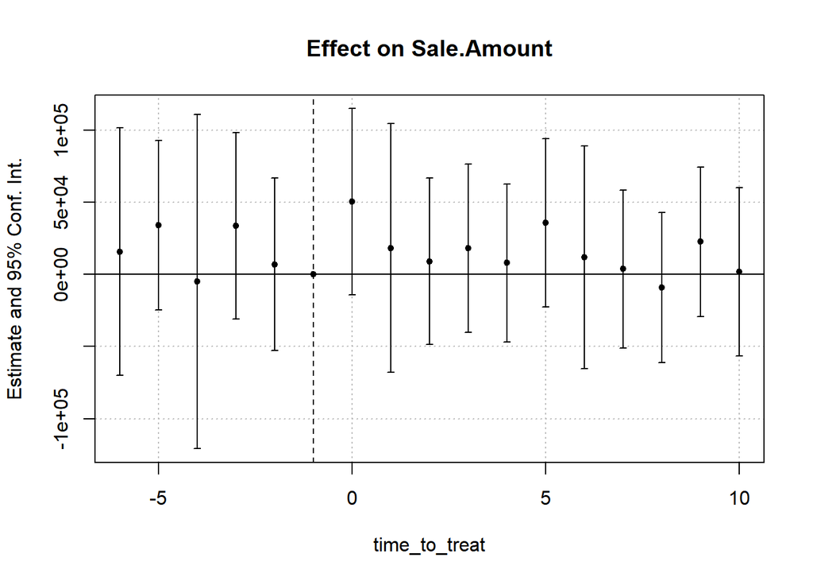

### Regressions:

```r
#all yaers
library("fixest")
Ct_hp<-read.csv("C:/Users/leora/Documents/ECON 400/Project/Real_Estate_Sales_2001-2021_GL_Schooldistricts.csv")

Ct_hp$month <- month(mdy(Ct_hp$Date.Recorded))
Ct_hp$day <- day(mdy(Ct_hp$Date.Recorded))
Ct_hp$year <-year(mdy(Ct_hp$Date.Recorded))

Ct_hp<-Ct_hp[!Ct_hp$Residential.Type =="",] #removing nonresidential

Ct_hp<-Ct_hp[Ct_hp$Sale.Amount > 100000,] #Arm lengths transactions... transactions > $100,000

Ct_hp$treatment<- ifelse(Ct_hp$Town == "Newtown",1,0) #binary treatment variable

Ct_hp$post<- ifelse(Ct_hp$year> 2012 | (Ct_hp$year == 2012 & Ct_hp$month== 12 & Ct_hp$day > 14), 1, 0) #binary post treatment variable

ct_hp<-cbind(Ct_hp[,c("treatment", "Sale.Amount","post", "Town","year", "Assessed.Value", "Residential.Type")])

reg_twfe<-feols(log(Sale.Amount) ~ treatment:post | Town + year,
                data= ct_hp,
                se = "iid")

reglm<-lm(log(Sale.Amount)~ treatment + post + treatment:post +as.factor(Town) + as.factor(year), data=ct_hp)

reglm1<-lm(log(Sale.Amount)~ treatment + post + treatment:post +as.factor(Town) + as.factor(year) +as.factor(Residential.Type), data=ct_hp)




library("modelsummary")

regz<- list('2X2 DiD' = reglm,
            'Town+Yr FE' = reg_twfe,
            'Town +Yr+Res.Type' =reglm1)
coefz<- c("treatment:post" = "Newtown:Post",
          "treatment"= "Newtown",
          "post" = "Post")
gofz<- c("nobs", "r.squared")
modelsummary(regz,
             title= "Shootings on Log(Housing Prices)",
             estimate= "{estimate}{stars}",
             coef_map= coefz,
             gof_map = gofz)
```

Shootings on Log(Housing Prices)

|  | 2X2 DiD | Town+Yr FE | Town +Yr+Res.Type |
| --- | --- | --- | --- |
| Newtown:Post | −0.020 | −0.020 | −0.016 |
|  | (0.016) | (0.016) | (0.016) |
| Newtown | 0.235*** |  | 0.153*** |
|  | (0.016) |  | (0.015) |
| Post | −0.032 |  | −0.050 |
|  | (0.084) |  | (0.081) |
| Num.Obs. | 30954 | 30954 | 30954 |
| R2 | 0.248 | 0.248 | 0.299 |